# NLP - Twitter Sentiment Analysis

Jaime Fomperosa

25/01/2022

# Libraries for text analysis

pacman automatically installs all the missing libraries instead of returning an error when loading them.

```r
if (!require("pacman")) install.packages("pacman")
```

```r
# pacman automatically installs missing libraries before loading
pacman::p_load(
  rtweet, # load twitter library
  ggplot2, # plotting
  dplyr, # pipes
  tidytext, # text mining library
  tm,
  wordcloud2,
  stringr,
  xts,
  textdata
)
```

We set the variables with the credentials to use the Twitter API (substitute these fields with yours)

```r
appname <- "SentimentAnalysisR_JF"
key <- "XXXXXXXXXXXXXXXXXXXXXXXX"
secret <- "XXXXXXXXXXXXXXXXXXXXXXXX"
access_token <- "XXXXXXXXXXXXXXXXXXXXXXXX"
access_secret <- "XXXXXXXXXXXXXXXXXXXXXXXX"
```

It is necessary to create a token before making request through the API, the first time uncomment the create_token call

```r
# create token named "twitter_token"
#twitter_token <- create_token(
#  app = appname,
#  consumer_key = key,
#  consumer_secret = secret,
#  access_token = access_token,
#  access_secret = access_secret)

# In following sessions just use this, it gets stored as a system variable
get_token()
```

```
## <Token>
## <oauth_endpoint>
##  request:   https://api.twitter.com/oauth/request_token
##  authorize: https://api.twitter.com/oauth/authenticate
##  access:    https://api.twitter.com/oauth/access_token
## <oauth_app> SentimentAnalysisR_JF
##   key:    dmzIsjOyubraATGINPg2XZRu6
##   secret: <hidden>
## <credentials> oauth_token, oauth_token_secret
## ---
```

Some constants to define the analysis To make the same analysis on a different topic, changing the variables here should be enough

```r
HASHTAG <- "#bitcoin"
N <- 2000
LANG <- "en"
VERIFIED_ONLY <- TRUE
COLS_TO_DEL <- "quoted|retweet|coords|location|place|media|url|lang|reply|count|mentions|display|description|protected|source|quote"

QUERY <- if(!VERIFIED_ONLY) HASHTAG else paste(HASHTAG, "filter:verified", sep = " ")
```

The N most recent tweets with the selected query are retrieved

```r
tweets <- search_tweets(q = QUERY,
                        n = N,
                        include_rts = FALSE,
                        parse = TRUE,
                        lang = LANG,
                        retryonratelimit = TRUE
                        )
```

Unnecessary columns are removed

```r
del_cols <- function(tw) {
  filters <- COLS_TO_DEL
  cols.del <- colnames(tw) %>%
    str_subset(filters, negate = TRUE)
  return(select(tw, cols.del))
}
tweets <- del_cols(tweets)
```

```
## Note: Using an external vector in selections is ambiguous.
## ℹ Use `all_of(cols.del)` instead of `cols.del` to silence this message.
## ℹ See <https://tidyselect.r-lib.org/reference/faq-external-vector.html>.
```

Some tweets are shown to get an idea of what we are working with

```r
head(tweets$text, n = 10)
```

```
##  [1] "This is like my 9th or 10th crash.\n\nUsually this is where the biggest opportunities are. \n\nThis is when you could have bought $SHIB for $.000003 -- or #Bitcoin for $3K. \n\nIt all always comes back bigger :) Just a question of when.\n\nSo I've bought a few things, now going outside."
##  [2] "@JackieMoooon @danielesesta @0xSifu hahah yeah, no. \n\nDaniele wouldn't be able to go out in public for the rest of his life :D \n\nThis is temporary pain -- even #Bitcoin dumped to $3K once in the past three years."
##  [3] "If I were a bad person in charge of the fiat treasury -- and thus I could print as much as I wanted -- and if I were afraid of hard money like #Bitcoin and gold -- why wouldn't I print, buy BTC / gold, dump, repeat? \n\nWould that be noticed? Or could I operate undetected?"
##  [4] "Rio puts 1% of city balance into #Bitcoin.\n\nLatin America gets why crypto is not just important, but *imperative* to embrace early in the cycle. \n\nTheir citizens will benefit, while US citizens wallow in the effects of backwards politicians. \n\nFrom the @APompliano newsletter. https://…
##  [5] "#Bitcoin downgrades Moody's relevance. https://t.co/ORaFJZpCO3"
##  [6] "#Bitcoin dominance is rising. Will we still see an #altcoinseason in Q1 of 2022?\n\n👇🏻👇🏻👇🏻"
##  [7] "#Crypto users could top 1B by 2023 as nations continue to adopt #Bitcoin.\n\nhttps://t.co/kQ7624G7YP"
##  [8] "Investing in #Bitcoin is 🅿️"
##  [9] "What happens to alts if #Bitcoin does this again? \U{01f972} https://t.co/EnI1TPgkYK"
## [10] "#Bitcoin is dumping. Will it hold above $38,000?\n\nNo         Maybe       Yes\n👇            👇              👇"
```

## Checking the encoding

Install or load the necessary library

```r
p_load(utf8)
```

Check if there are any invalid characters in the tweets

```r
tweets$text[!utf8_valid(tweets$text)]
```

```
## character(0)
```

Normalize tweets and count differences

```r
tweets.norm <- utf8_normalize(tweets$text)
sum(tweets.norm != tweets$text)
```

```
## [1] 0
```

All tweets already had a normalized encoding

### Some exploration

We check how long the tweets are

```r
hist_tweets_len <- function(texts) {
  hist(nchar(texts),
     main = "Histogram of tweets length",
     xlab = "Number of characters")
}
```

Use the previous function for the actual plotting

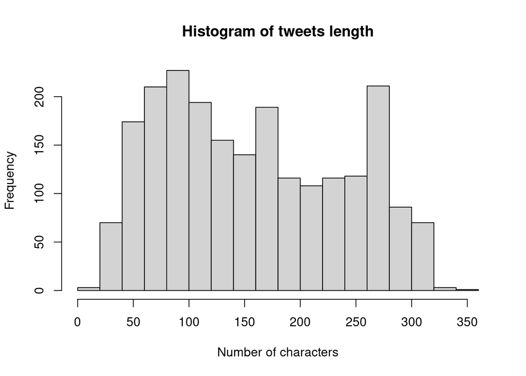

```r
hist_tweets_len(tweets$text)
```

## Data cleaning

Function for cleaning the text by removing links, usernames, line breaks, punctuation signs, etc.

```r
clean_text <- function(text) {
  ct <- gsub(HASHTAG, "", text)
  ct <- gsub("http\\S*", "", text)
  ct <- gsub("@\\S*", "", ct)
  ct <- gsub("&amp;", " ", ct)
  ct <- gsub("[\r\n]{1,}", " ", ct)
  ct <- gsub("[[:punct:]]", "", ct)
  ct <- gsub("[[:digit:]]", "", ct)
  ct <- gsub(" {2,}", " ", ct)
  return(ct)
}
```

### Tweets before cleaning the text

```r
head(tweets$text, n = 10)
```

```
##  [1] "This is like my 9th or 10th crash.\n\nUsually this is where the biggest opportunities are. \n\nThis is when you could have bought $SHIB for $.000003 -- or #Bitcoin for $3K. \n\nIt all always comes back bigger :) Just a question of when.\n\nSo I've bought a few things, now going outside."
##  [2] "@JackieMoooon @danielesesta @0xSifu hahah yeah, no. \n\nDaniele wouldn't be able to go out in public for the rest of his life :D \n\nThis is temporary pain -- even #Bitcoin dumped to $3K once in the past three years."
##  [3] "If I were a bad person in charge of the fiat treasury -- and thus I could print as much as I wanted -- and if I were afraid of hard money like #Bitcoin and gold -- why wouldn't I print, buy BTC / gold, dump, repeat? \n\nWould that be noticed? Or could I operate undetected?"
##  [4] "Rio puts 1% of city balance into #Bitcoin.\n\nLatin America gets why crypto is not just important, but *imperative* to embrace early in the cycle. \n\nTheir citizens will benefit, while US citizens wallow in the effects of backwards politicians. \n\nFrom the @APompliano newsletter. https://…
##  [5] "#Bitcoin downgrades Moody's relevance. https://t.co/ORaFJZpCO3"
##  [6] "#Bitcoin dominance is rising. Will we still see an #altcoinseason in Q1 of 2022?\n\n👇🏻👇🏻👇🏻"
##  [7] "#Crypto users could top 1B by 2023 as nations continue to adopt #Bitcoin.\n\nhttps://t.co/kQ7624G7YP"
##  [8] "Investing in #Bitcoin is 🅿️"
##  [9] "What happens to alts if #Bitcoin does this again? \U{01f972} https://t.co/EnI1TPgkYK"
## [10] "#Bitcoin is dumping. Will it hold above $38,000?\n\nNo         Maybe       Yes\n👇            👇              👇"
```

## Actual cleaning and tweets after cleaning the text

```r
tweets$text <- clean_text(tweets$text)
head(tweets$text, n = 10)
```

```
##  [1] "This is like my th or th crash Usually this is where the biggest opportunities are This is when you could have bought SHIB for or Bitcoin for K It all always comes back bigger Just a question of when So Ive bought a few things now going outside"
##  [2] " hahah yeah no Daniele wouldnt be able to go out in public for the rest of his life D This is temporary pain even Bitcoin dumped to K once in the past three years"
##  [3] "If I were a bad person in charge of the fiat treasury and thus I could print as much as I wanted and if I were afraid of hard money like Bitcoin and gold why wouldnt I print buy BTC gold dump repeat Would that be noticed Or could I operate undetected"
##  [4] "Rio puts of city balance into Bitcoin Latin America gets why crypto is not just important but imperative to embrace early in the cycle Their citizens will benefit while US citizens wallow in the effects of backwards politicians From the newsletter "
##  [5] "Bitcoin downgrades Moodys relevance "
##  [6] "Bitcoin dominance is rising Will we still see an altcoinseason in Q of "
##  [7] "Crypto users could top B by as nations continue to adopt Bitcoin "
##  [8] "Investing in Bitcoin is 🅿"
##  [9] "What happens to alts if Bitcoin does this again \U{01f972} "
## [10] "Bitcoin is dumping Will it hold above No Maybe Yes "
```

Now the number of characters is consistent with the max length of a tweet (280)

```r
max(nchar(tweets$text))
```

```
## [1] 275
```

## Number of chars per tweet after cleaning

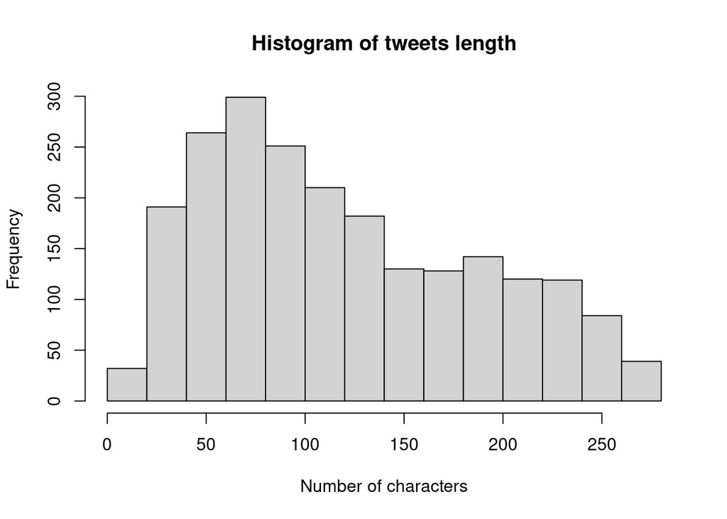

```r
hist_tweets_len(tweets$text)
```

For ease in temporal analysis later, all date times are rounded to the hour

```r
tweets$created_hour <- tweets$created_at %>% round(units = "hours")
```

We separate the tweets into individual words to count their frequency

```r
tweets.unnested <- unnest_tokens(tweets, words, text)
head(tweets.unnested$words, n = 20)
```

```
##  [1] "this"          "is"            "like"          "my"
##  [5] "th"            "or"            "th"            "crash"
##  [9] "usually"       "this"          "is"            "where"
## [13] "the"           "biggest"       "opportunities" "are"
## [17] "this"          "is"            "when"          "you"
```

Before counting, stop words should be removed

```r
sw <- data.frame(words = stopwords(LANG))
tweets.unnested <- anti_join(tweets.unnested, sw)
```

A word cloud to illustrate most relevant words for this hashtag

```r
wordcloud2(tweets.unnested %>% count(words))
```

[interactive chart not shown]

These are the words that are being used in relationship with the searched topic the most

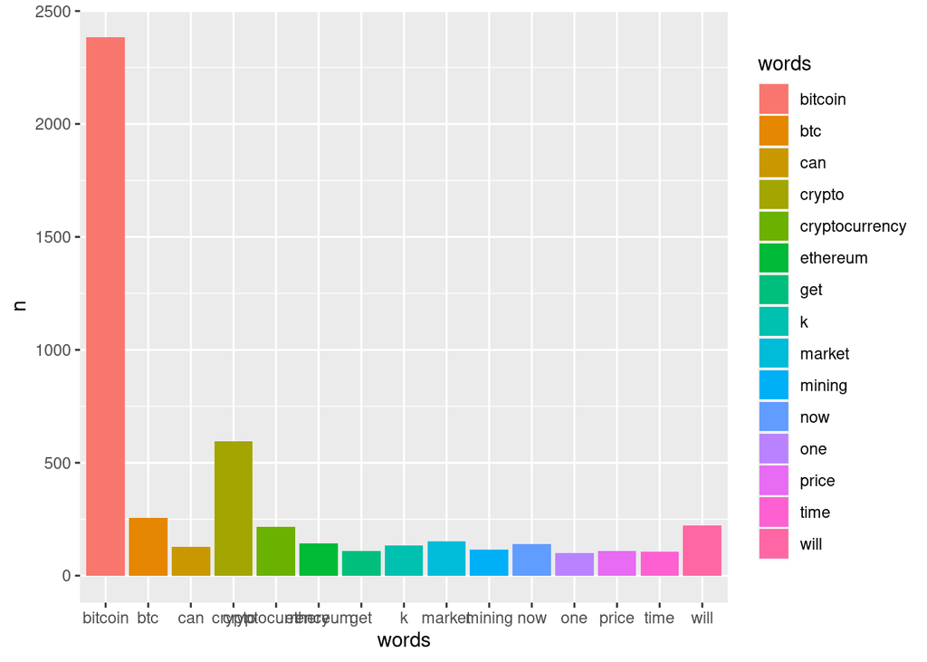

```r
ggplot(
  tweets.unnested %>% count(words) %>% arrange(desc(n)) %>% head(15),
  aes(x = words, y = n, fill = words)
) + geom_col()
```

## Who is tweeting about this?

```r
wordcloud2(tweets %>% count(screen_name))
```

[interactive chart not shown]

Some prolific tweeters but also many smaller ones.

These are the counts with the highest number of tweets.

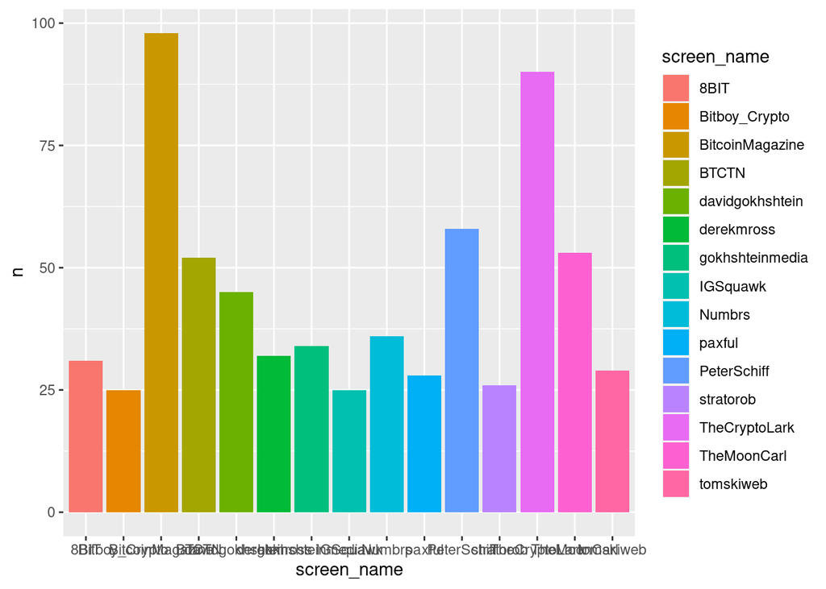

```r
ggplot(
  tweets %>% count(screen_name, sort=TRUE) %>% arrange(desc(n)) %>% head(15),
  aes(x = screen_name, y = n, fill = screen_name)
) + geom_col()
```

Some accounts are posting many tweets, but nothing weird as they are probably accounts dedicated to crypto stuff. Not filtering to get only verified accounts did result on a large number of tweets from (probably) bots.

# Sentiment Analysis

Several lexicons for sentiment analysis in tidytext package: - bing: binary (positive or negative) - afinn: numeric (from -5 to 5, most negative to most positive) - loughran: financial terms (pos, neg, litigious, …) - nrc: categorical (whether each word belongs to a certain category - pos, neg, anger, fear, joy…)

For our purpose, bing and afinn will be used.

```r
sents.afinn <- get_sentiments("afinn")
sents.bing <- get_sentiments("bing")
head(sents.afinn, n = 5)
```

```
## # A tibble: 5 × 2
##   word      value
##   <chr>     <dbl>
## 1 abandon      -2
## 2 abandoned    -2
## 3 abandons     -2
## 4 abducted     -2
## 5 abduction    -2
```

We associate each word with its sentiment obtained from the lexicons

```r
tweets.afinn <- tweets.unnested %>%
  inner_join(sents.afinn, by = c("words" = "word"))
tweets.bing <- tweets.unnested %>%
  inner_join(sents.bing, by = c("words" = "word"))
```

Some words classified using the afinn lexicon

```r
tweets.afinn %>% select(words, value)
```

```
## # A tibble: 2,423 × 2
##    words         value
##    <chr>         <dbl>
##  1 like              2
##  2 crash            -2
##  3 opportunities     2
##  4 yeah              1
##  5 pain             -2
##  6 dumped           -2
##  7 bad              -3
##  8 afraid           -2
##  9 hard             -1
## 10 like              2
## # … with 2,413 more rows
```

Some words classified using the bing lexicon

```r
tweets.bing %>% select(words, sentiment)
```

```
## # A tibble: 2,552 × 2
##    words  sentiment
##    <chr>  <chr>
##  1 like   positive
##  2 crash  negative
##  3 pain   negative
##  4 dumped negative
##  5 bad    negative
##  6 afraid negative
##  7 hard   negative
##  8 like   positive
##  9 gold   positive
## 10 gold   positive
## # … with 2,542 more rows
```

# AFINN lexicon

```r
tweets.scores.afinn <- tweets.afinn %>%
  group_by(created_hour) %>%
  summarise(.groups = "keep", score = sum(value))
```

The results are transformed into a time series and plotted

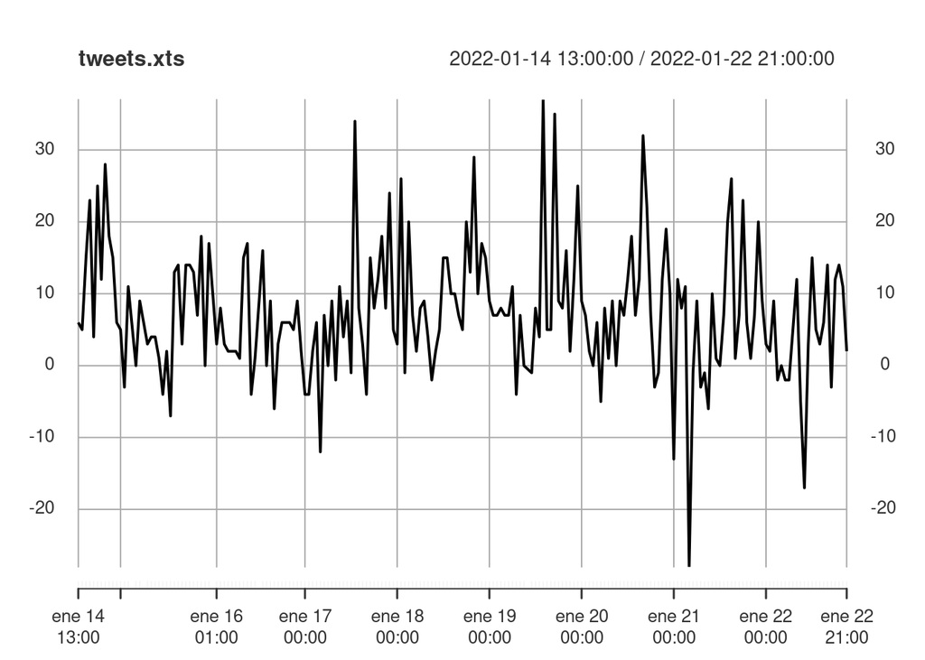

```r
tweets.xts <- xts(tweets.scores.afinn$score, order.by = tweets.scores.afinn$created_hour)
plot(tweets.xts)
```

The frequencies of different scores for this lexicon

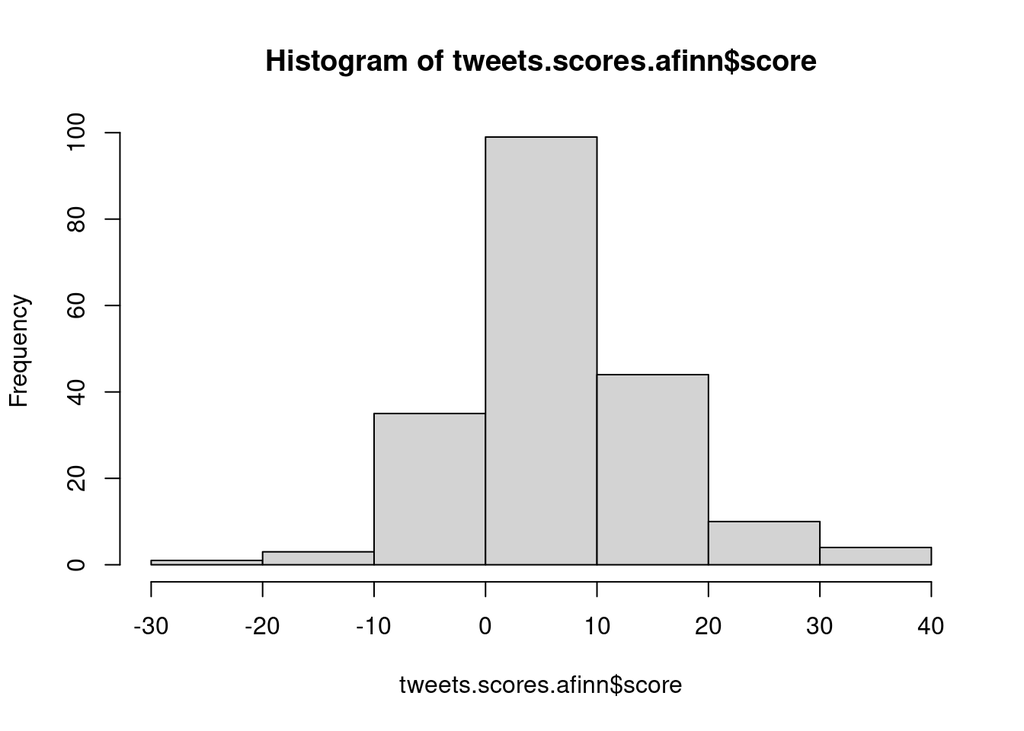

```r
hist(tweets.scores.afinn$score)
```

# Bing lexicon

```r
tweets.scores.bing <- tweets.bing %>%
  group_by(created_at, user_id, created_hour) %>%
  summarise(.groups = "keep", pos = sum(sentiment == "positive"), neg = sum(sentiment == "negative")) %>%
  mutate(overall = sum(pos - neg)) %>%
  mutate(score = sign(overall)) %>%
  group_by(created_hour) %>%
  summarise(.groups = "keep", score = sum(score))
```

The results are transformed into a time series and plotted

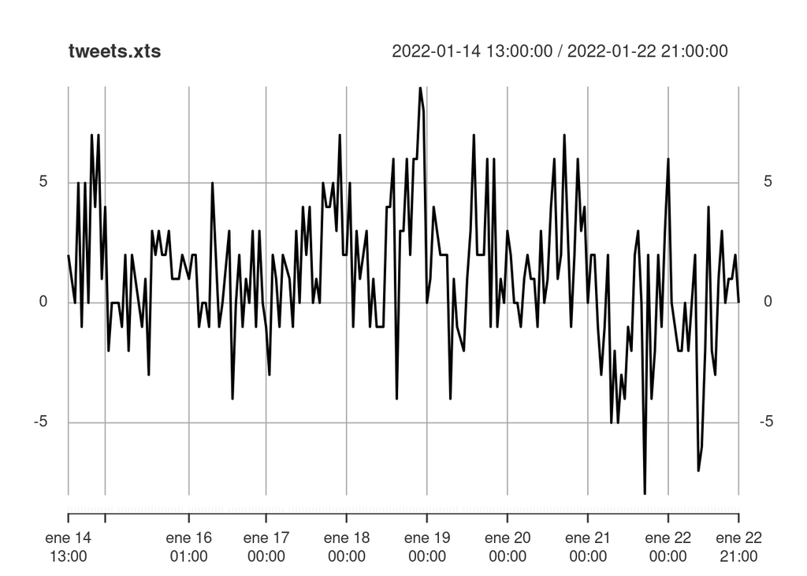

```r
tweets.xts <- xts(tweets.scores.bing$score, order.by = tweets.scores.bing$created_hour)
plot(tweets.xts)
```

The frequencies of different scores for this lexicon

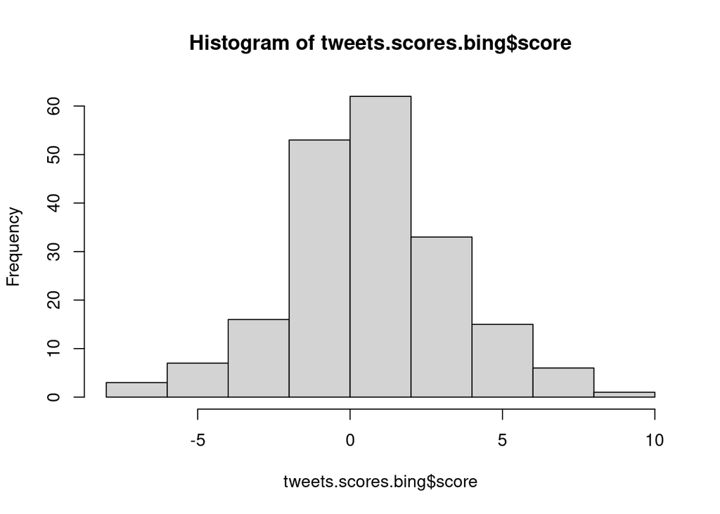

```r
hist(tweets.scores.bing$score)
```